# r_sample: generate simulated data

Michael D Evans

5/16/2021

In this sample, I generate some **simulated data** for a study where participants complete some surveys and play a game that measures risk assessment (game link below!). Participants will be in two groups, a treatment group (“group1”) and a no-treatment group (“group2”).

The hypotheses I am testing are whether participants in the treatment group are more accurately able to assess risk, whether there are differences in survey responses for the groups, and which items from the surveys are most strongly associated with performance.

Survey: five facet mindfulness questionnaire (39 items) Behavioral Task: Ice Cream Game (try it out: www.mdevans.me/projects/icecream; adapted from BART task, Lejuez et al. 2002 http://www.impulsivity.org/measurement/BART)

The goal in the Ice Cream Game is to sell as much ice cream using as few cones as possible (e.g. sell as many scoops of ice cream as possible for each trial). Each scoop increases the reward value +1. At any point (even the first scoop), the ice cream can fall, and you cannot sell any- you receive 0 points and move onto the next trial. The risk of the scoops falling increases with each additional scoop, with it guaranteed to fall by the 64th scoop (1/64 probability on the first scoop, 32/64 on the 32nd scoop, etc.). Optimal behavior would be to sell the ice cream when the probability of failure is as close to 50% as possible, in this case, at 32 scoops. Fewer scoops results in missing out on probable reward, and more scoops results in unnecessary risk.

```r
n<-1000 # set TOTAL number of subjects
n_groups<-2 # number of groups, subject numbers randomly assigned
participants <- sample.int(1e3, n) #assign random subject ids 1-1000
group1 <- participants[1:(n/2)] # first half to group1
group2 <- participants[((n/2)+1):n] # second half to group2
length(group1)==length(group2) && length(group1)==(n/2) # check lengths match up
```

```
## [1] TRUE
```

```r
# create main data table, populate some fields
# columns: subj, group, age, gender, ffmq1, ffmq2...bis1, bis2...ic_risk, ic_total, ic_mean, ic_rt
df <- data.frame(
  id = c(group1,group2), # combine participants (could also just use participants)
  group = c(rep(1,(n/2)),rep(2,(n/2))), # assign group number
  age = runif(n,18,55) # generate ages, random sample uniform dist range 18-55
)

# other fields require more nuanced distributions

# gender
# we'll sample gender from categorical dist (.49male, .49female, .2non-binary/other)
# well use random uni dist 0-1, 0-.49 = m, .49-.98 = f, >=.98 = nb
# since we're using random numbers, our sample may not perfectly reflect our simulated population e.g. may have 0 non-binary individuals
m<-0.49 # e.g 49%
f<-0.49
nb<-1-m-f # remainder *note rule: m+f<=1
gender = runif(n) # generate n-number values 0-1 random uniform dist.

for (ii in 1:n){ # counter to go through each gender item
  if (gender[ii]<m){ # if value below male threshold
    gender[ii]<-'m'
    next # skip to next counter item otherwise value overwritten
  }else if (gender[ii]<m+f){ # if value greater than male,but less than male+female
    gender[ii]<-'f'
    next
  }else{ # <= m+f
    gender[ii]<-'nb'
  }
}
df$gender = gender # add to our dataframe
```

```r
## survey data
# first survey is five facet mindfulness questionnaire, 39 items w 5 factors

# we hypothesized that treatment (group1) would score higher than control (group2), so we'll set anchors for those as well.
# item responses range 1-5
m_ffmq_g1 <- 3.5 # mean ffmq score for group1
sd_ffmq_g1 <- 1 # sd ffmq score, group1

m_ffmq_g2 <- 3
sd_ffmq_g2 <- 1

# we'll generate data such that a factor analysis should reveal the factors by setting different anchors for each factor, and generative values for associated questions from those anchors
# factor: factor_name(factor_items)
# factor1: observing (1, 6, 11, 15, 20, 26, 31, 36)
obs_items = c(1,6,11,15,20,26,31,36) # we'll use later when generating data matrices
# factor2: describing (2, 7, 12R, 16R, 22R, 27, 32, 37)
desc_items = c(2,7,12,16,22,27,32,37)
# factor3: awareness (5R, 8R, 13R, 18R, 23R, 28R, 34R, 38R)
aware_items = c(5,8,13,18,23,28,34,38)
# factor4: nonjudging (3R, 10R, 14R, 17R, 25R, 30R, 35R, 39R)
nj_items = c(3,10,14,17,25,30,35,39)
# factor5: nonreactivity (4, 9, 19, 21, 24, 29, 33)
nr_items = c(4,9,19,21,24,29,33)

minMax <- function(m,floor=1,ceiling=5){
# function to set floor and ceiling values in a matrix
  m[m<floor]<-floor # set any values less than floor to floor
  m[m>ceiling]<-ceiling # same for ceiling
  return(m)
}

removeItems <- function(m,factor_items){
# function to remove non-factor items from matrix
  m_vec <- to_vec(for(i in 1:39) # create vector for item placement,
    if(i %in% factor_items) 1 else 0)  # 1s in question index associated w factor, else NA

  for (ii in 1:length(m_vec)){ # go through binary vector representing factor items
    m[,ii]<-m[,ii]*m_vec[ii] #  if 0, drop column, if 1, keep column as is
  }
  return(m)
}

gen_factor_data <-function(factor_items,print_plot=FALSE){
# function to generate ffmq factor data
# input: factor indicies
# output: 200x39 matrix of factor item responses (non-factor filled w 0s)
#   rows 1:100: group1
#   rows 101:200: group2
  m <- c(rnorm(length(group1),m_ffmq_g1,sd_ffmq_g1), # generate mean factor score for group1
           rnorm(length(group2),m_ffmq_g2,sd_ffmq_g2)) # and group2
  m = matrix(rnorm(39*n,m,1),n,39) # generate matrix using random means (static per participant)

  # using this method, we'll get some float values instead of integer
  mode(m)<-'integer' # set internal storage mode to integer (truncates)

  # we'll also run into values outside our range of 1-5
  m<-minMax(m)

  # good time to print some histograms to make sure distribution is as-expects
  if(print_plot==TRUE){
    hist(m[1:100,]) # first 100 rows e.g group1
    abline(v=m_ffmq_g1,col='red') # plot group1 population mean

    hist(obs[101:200,])# group2
    abline(v=m_ffmq_g2,col='red')
  }

  # get rid of non-factor columns
  m<-removeItems(m,factor_items)
  return(m)
}

# generate factor item responses
obs <- gen_factor_data(obs_items)
desc <- gen_factor_data(desc_items)
aware <- gen_factor_data(aware_items)
njudge <- gen_factor_data(nj_items)
nreact <- gen_factor_data(nr_items)

# as is, all factors have the same means since they were generated w same population values
# let's add some variability between factors

obs<-obs-1 # lower all obs scores by 1
obs<-minMax(obs) # reset floor/ceiling
obs<-removeItems(obs,obs_items) # 1 added to 0 values, remove non-factor columns

njudge[1:100,]<-njudge[1:100,]+1 # increase tx group non-judge by 1
njudge<-minMax(njudge)
njudge<-removeItems(njudge,nj_items)

nreact[1:100,]<-nreact[1:100,]+1 # increase tx group nreact
nreact<-minMax(nreact)
nreact<-removeItems(nreact,nr_items)

aware[101:200,]<-aware[101:200,]+1 # increase control group aware
aware<-minMax(aware)
aware<-removeItems(aware,aware_items)

desc[101:200,]<-desc[101:200,]+1 # increast ctrl group desc
desc<-minMax(desc)
desc<-removeItems(desc,desc_items)

# since we counter-balanced updating values, overall mean for groups should be the same
# so simply comparing group1 v group2 should show sig diff.
# When we break down FFMQ data, we should be able to see which factors contribute most to this diff

ffmq = data.frame(obs+desc+aware+njudge+nreact) # combine to create final ffmq data frame

# add to main df
df$ffmq = ffmq
```

Now lets pretend that some of these traits are related to task performance- non-judgement (nj) and non-react (nr).

Since these are the factors where the two groups differ most, we should see a main group effect. Then, when we do a factor analysis to see which factors best predict performance, we should see that it was the factors that the treatment was most influential on - nj and nr.

It is also a good idea to replicate some typical, known behaviors. For example, we know age is generally positively correlated with risk aversion - older people tend to be more cautious in these kinds of games.

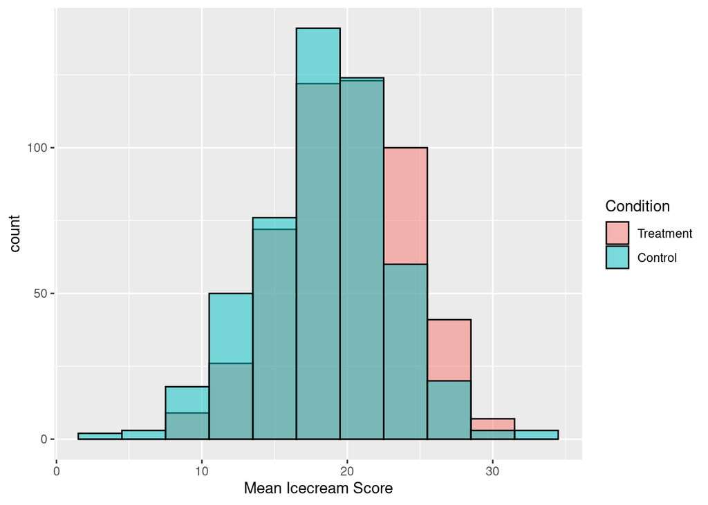

```r
# icecream game

# calculate nj and nr scores for each row
calcScoops = function(vec,age){

  # get response for each nj_item, normalize by max (n items * max valid response (5))
  nj_score = sum(to_vec(for(i in 1:length(vec)) if (i %in% nj_items) vec[i])) /(length(nj_items)*5)
  nr_score = sum(to_vec(for(i in 1:length(vec)) if (i %in% nr_items) vec[i])) /(length(nr_items)*5)

  mean = (16-((age-18)/(55-18))/.2)+(4*nj_score)+(6*nr_score) # calculate mean using defined equation
  sd = 3/(.5+(.25*nj_score)+(.25*nr_score)) #  and standard deviation

  scoops = rnorm(1, mean, sd) # pull from distribution


  # don't want negative (or even very low) values!
  if(scoops<4){scoops=scoops+4}

  return(scoops)
}
for (row in 1:nrow(df)){
  vec = df$ffmq[row,]
  age = df$age[row]
  df$ic_scoops[row]=calcScoops(vec,age)
}

plt<-ggplot(data=df, aes=(x=ic_scoops))+ # plot as histogram to check distributions
  geom_histogram(mapping=aes(x=ic_scoops, fill=as.factor(group)),binwidth=3,position='identity',color='black',alpha=0.5)+
  labs(fill='Condition',x='Mean Icecream Score')+
  scale_fill_discrete(labels=c('Treatment','Control'))
print(plt) # display plot
```

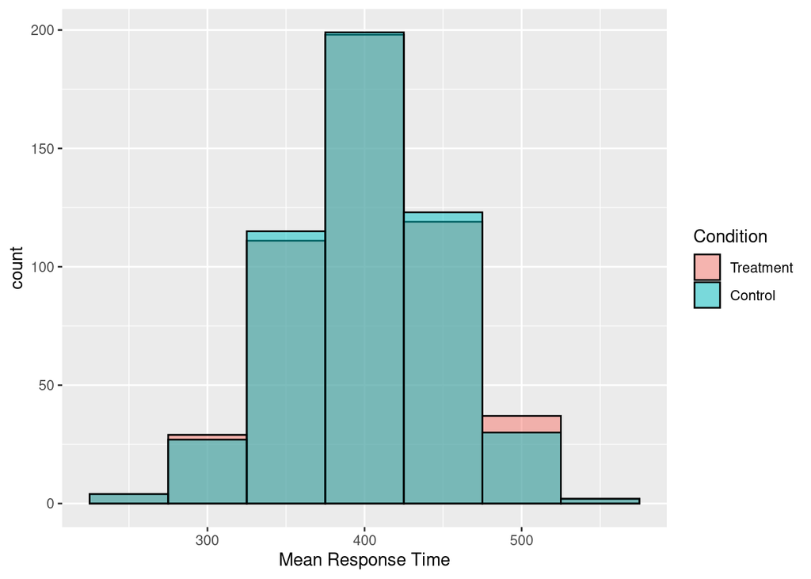

```r
# any reason to think reaction times would be different between groups?
# if not, just assign from norm. dist w reasonable time (fast game, so expect low rt)
m_rt<-400
sd_rt<-50
df$ic_rt = rnorm(n,m_rt,sd_rt) # normal dist., add to dataframe
plt<-ggplot(data=df)+
  geom_histogram(mapping=aes(x=ic_rt,fill=as.factor(group)),binwidth=50,position='identity',color='black',alpha=0.5)+
  labs(fill='Condition',x='Mean Response Time')+
  scale_fill_discrete(labels=c('Treatment','Control'))
print(plt)
```

```r
# save as a csv and move onto analysis!
write.csv(df,paste(here(),'/ffmq_ic_data.csv',sep=''))
```